# An Ensemble Model to Predict the Presence of Gallstones: Development and Evaluation

DA5030

Gupta, Ankur

Summer 2025

```r
library(psych)
library(caret)
library(randomForest)
library(class)
library(glmnet)
library(dplyr)
```

## Data Explanation, Aquisition, and Exploration

### Project Explanation and Data Loading

```r
df <- read.csv("https://raw.githubusercontent.com/gupta99ankur/DA5030/main/dataset-uci.csv", stringsAsFactors = FALSE, header = TRUE)
```

### Data Exploration

```r
head(df, 5)
```

```
##   Gallstone.Status Age Gender Comorbidity Coronary.Artery.Disease..CAD.
## 1                0  50      0           0                             0
## 2                0  47      0           1                             0
## 3                0  61      0           0                             0
## 4                0  41      0           0                             0
## 5                0  42      0           0                             0
##   Hypothyroidism Hyperlipidemia Diabetes.Mellitus..DM. Height Weight
## 1              0              0                      0    185   92.8
## 2              0              0                      0    176   94.5
## 3              0              0                      0    171   91.1
## 4              0              0                      0    168   67.7
## 5              0              0                      0    178   89.6
##   Body.Mass.Index..BMI. Total.Body.Water..TBW. Extracellular.Water..ECW.
## 1                  27.1                   52.9                      21.2
## 2                  30.5                   43.1                      19.5
```

[output cut: 63 more lines]

```r
str(df)
```

```
## 'data.frame':    319 obs. of  39 variables:
##  $ Gallstone.Status                              : int  0 0 0 0 0 0 0 0 0 0 ...
##  $ Age                                           : int  50 47 61 41 42 96 37 41 38 38 ...
##  $ Gender                                        : int  0 0 0 0 0 0 0 0 0 0 ...
##  $ Comorbidity                                   : int  0 1 0 0 0 0 0 0 0 0 ...
##  $ Coronary.Artery.Disease..CAD.                 : int  0 0 0 0 0 0 0 0 0 0 ...
##  $ Hypothyroidism                                : int  0 0 0 0 0 0 0 0 0 0 ...
##  $ Hyperlipidemia                                : int  0 0 0 0 0 0 0 0 0 0 ...
##  $ Diabetes.Mellitus..DM.                        : int  0 0 0 0 0 0 0 0 0 0 ...
##  $ Height                                        : int  185 176 171 168 178 155 185 176 186 171 ...
##  $ Weight                                        : num  92.8 94.5 91.1 67.7 89.6 49 67.1 114 93.7 68.6 ...
##  $ Body.Mass.Index..BMI.                         : num  27.1 30.5 31.2 24 28.3 20.4 19.6 36.8 27.1 23.5 ...
##  $ Total.Body.Water..TBW.                        : num  52.9 43.1 47.2 41.4 51.4 34 41.8 57.6 51.9 39.5 ...
##  $ Extracellular.Water..ECW.                     : num  21.2 19.5 20.1 17 20 15.7 17.1 23.5 20.9 16.6 ...
##  $ Intracellular.Water..ICW.                     : num  31.7 23.6 27.1 24.4 31.4 18.3 24.7 34.1 31 22.9 ...
```

[output cut: 25 more lines]

```r
nrow(df)
```

```
## [1] 319
```

```r
ncol(df)
```

```
## [1] 39
```

```r
table(df$Gallstone.Status)
```

```
##
##   0   1
## 161 158
```

Our dataset contains 319 observations, 38 features and our target variable ‘Gallstone.Status’, which categorically indicates the presence of gallstone or not (1 or 0). Furthermore, there is no class imbalance for our target variable, Gallstone.Status.

Most of the features appear to be numeric, with several several categorical features.

#### Missing Values

Now lets assess missing values:

```r
which(is.na(df))
```

```
## integer(0)
```

Because we know there are no characters in any of the features, we can conclude that there are no missing values in the dataset. Although this is ideal, to ensure robustness of our model (and for project requirements), we will randomly delete data later in this project.

#### Categorical Features and Class Imbalance

We identified previously that there are several categorical features. Now, we will look at them more deeply, in particular, assess their class imbalance:

```r
all_feature_names <- setdiff(colnames(df), 'Gallstone.Status')
categorical_features <- character()

for (feature in all_feature_names){
  table_temp <- table(df[feature])

  if (length(table_temp) <= 2){
    categorical_features <- c(categorical_features, feature)
    print(table_temp)
  }
}
```

```
## Gender
##   0   1
## 162 157
## Coronary.Artery.Disease..CAD.
##   0   1
## 307  12
## Hypothyroidism
##   0   1
## 310   9
## Hyperlipidemia
##   0   1
## 311   8
## Diabetes.Mellitus..DM.
##   0   1
## 276  43
```

There are 5 categorical features in the dataset: Gender, Coronary.Artery.Disease..CAD., Hypothyroidism, Hyperlipidemia, Diabetes.Mellitus..DM.. Importantly, the feature Hepatic Fat Accumulation (HFA), although scales from 0~4 discretely, also is categorical in nature - any value above 0 denotes presence of hepatic fat (as described by the author of the data). Therefore, this feature can be treated as categorical if future model optimization is required. However, we will treat it as numeric but discrete and ordinal for now.

Furthermore, we also see that many of the categorical features are extremely imbalanced, in particular: hypothyroidism and hyperlipidemia. Although these are features, and not our target variable, they can pose significant issue depending upon the models used. For example, if one feature is strongly correlated with the presence of gallstones and it is strongly imbalanced, our models will over- or under-predict classification when using that feature.

Let us inspect the categorical features in question more by comparing them to our target feature:

```r
# Convert to data.frame for ggplot
table(df$Hyperlipidemia, df$Gallstone.Status)
```

```
##
##       0   1
##   0 161 150
##   1   0   8
```

Here we see that all observations, or patients, with hyperlipidemia have gallstones. This will pose significant issues for our models as it well strongly predict gallstones for any patients with hyperlipidemia. From domain knowledge, we know that hyperlipidemia is not a test to diagnose gallstones, therefore, if this model is applied to new data, there will be patients that have hyperlipidemia without gallstones. Our models would either be unable to, or find it difficult to accuratly predict their gallstone status. Furthermore, this class imbalance will inflate our models’ evaluation.

Since there are no examples of patients with hyperlipidemia but without gallstones, we will choose to not utilize this feature.

Assessing Hypothyroidism:

```r
table(df$Hypothyroidism, df$Gallstone.Status)
```

```
##
##       0   1
##   0 155 155
##   1   6   3
```

In the case of hypothyroidism, do not see a relationship between hypothyroidism and gallstone status. Therefore, we do need to inherently remove it like hyperlipidemia. Instead, we can prioritize models that can tolerate rare cases.

Finally, let us look at gender and diabetes status:

```r
table(df$Gender, df$Gallstone.Status)
```

```
##
##      0  1
##   0 94 68
##   1 67 90
```

```r
table(df$Diabetes.Mellitus..DM., df$Gallstone.Status)
```

```
##
##       0   1
##   0 145 131
##   1  16  27
```

For both gender and diabetes, there are minimal class imbalances with respect to gallstone status - i.e. there are all cases exist. Like hypothyroidism, it would be ideal to utilize models that can tolerate rarer cases.

#### Numeric Feature Inspection

Now let us inspect the numeric features in the dataset by looking it the distribution:

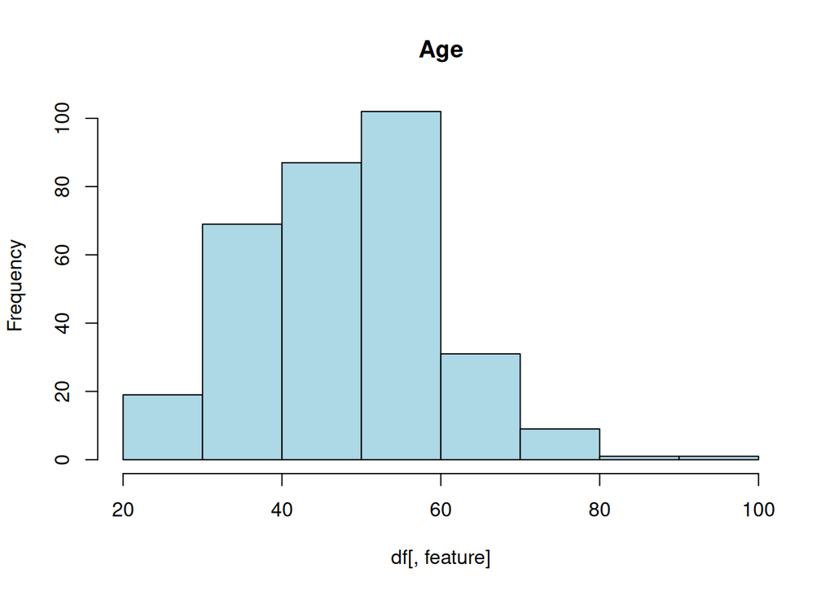

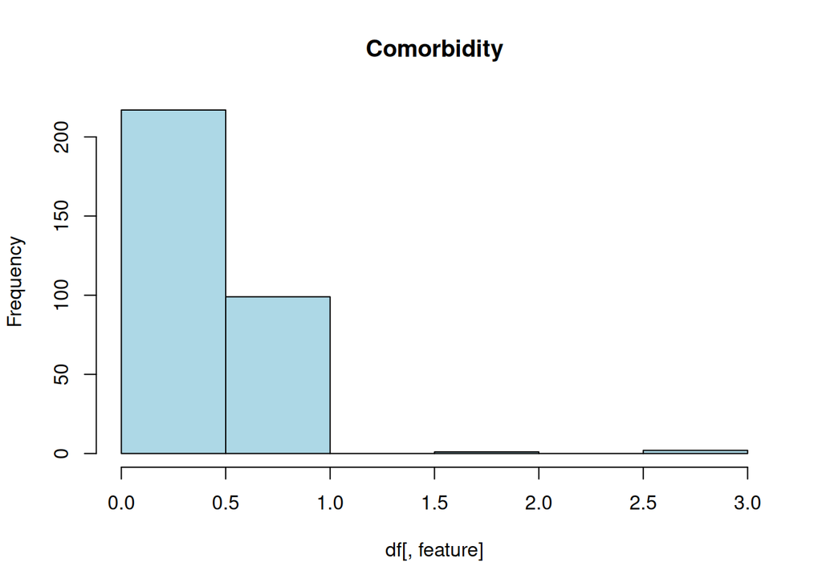

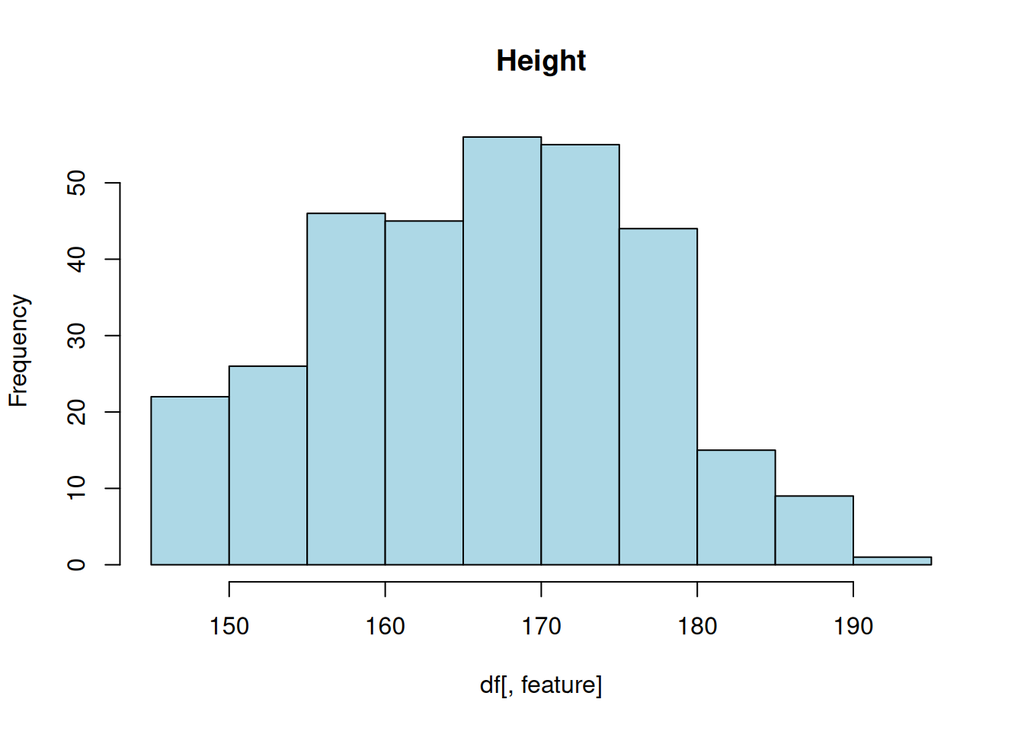

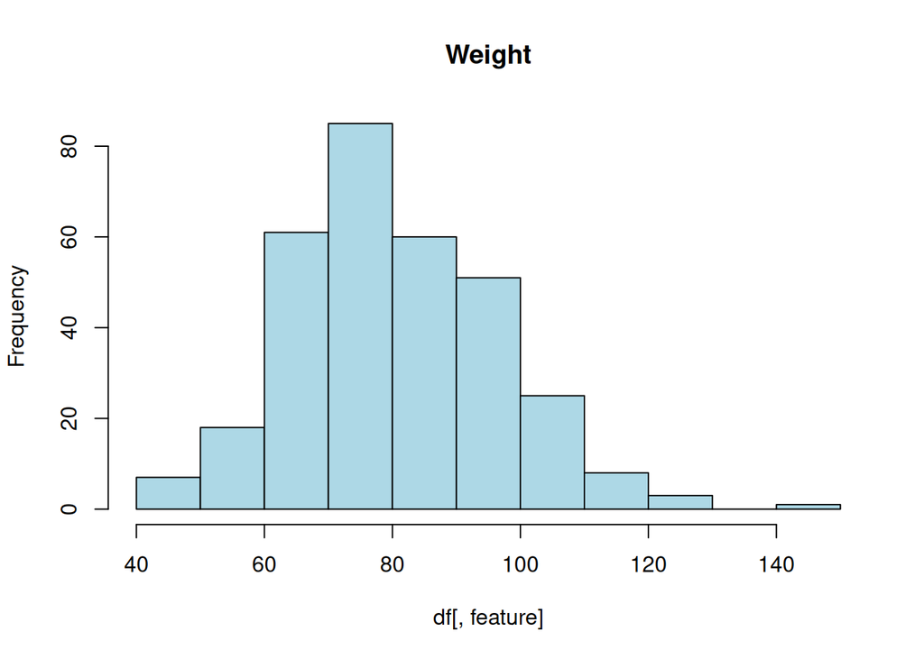

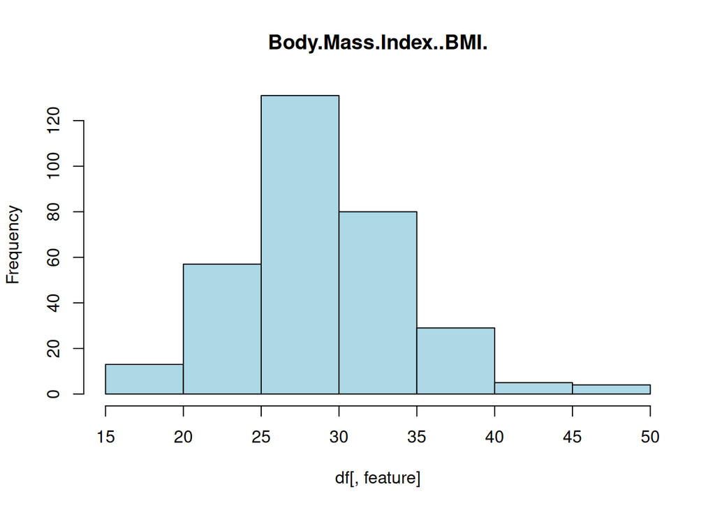

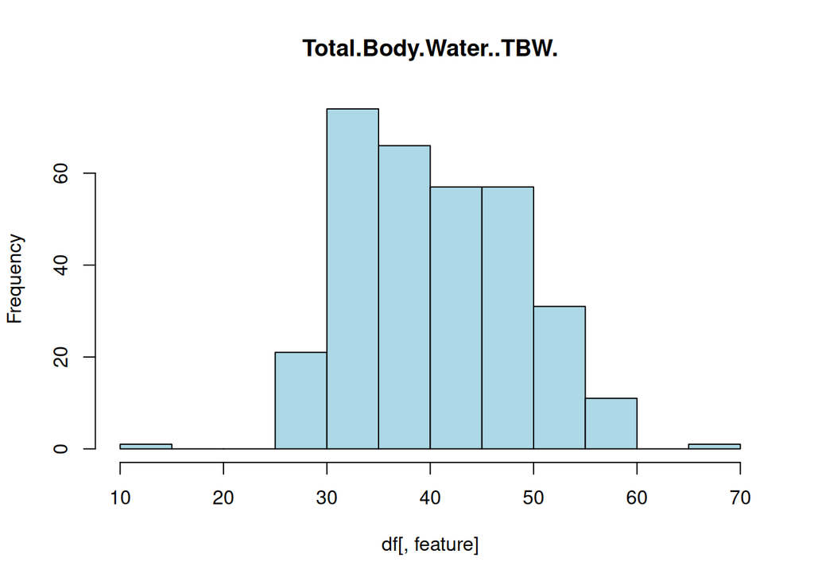

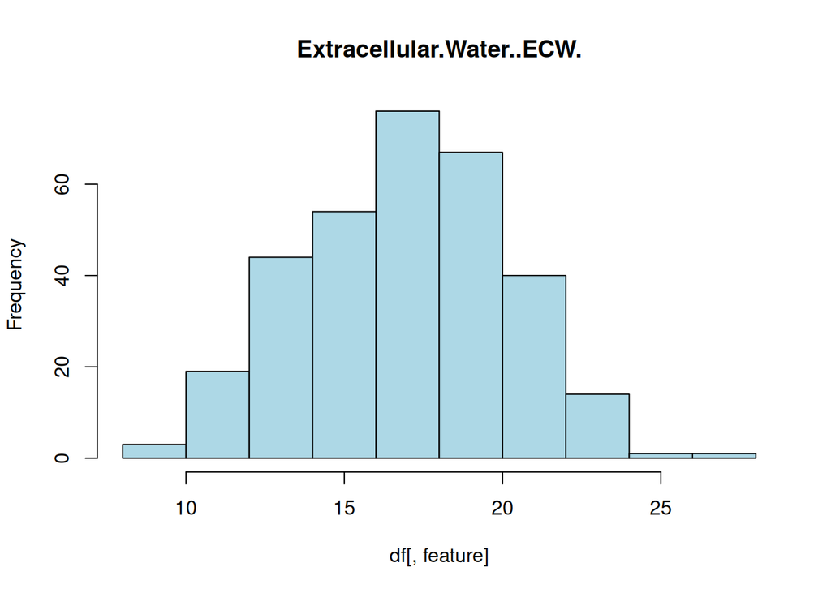

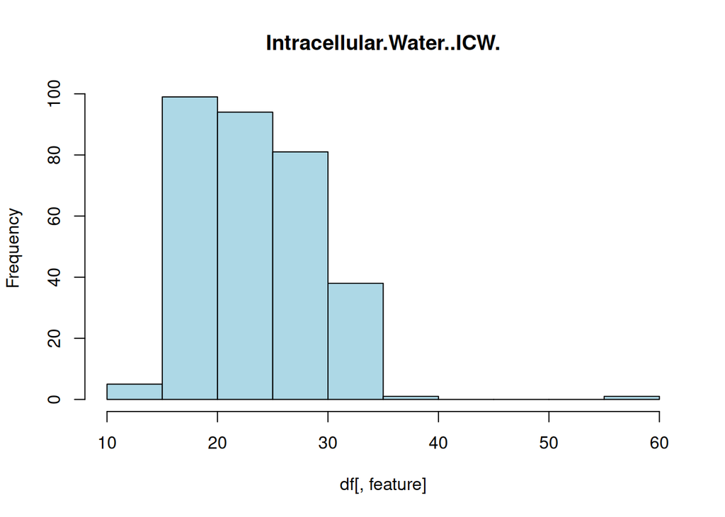

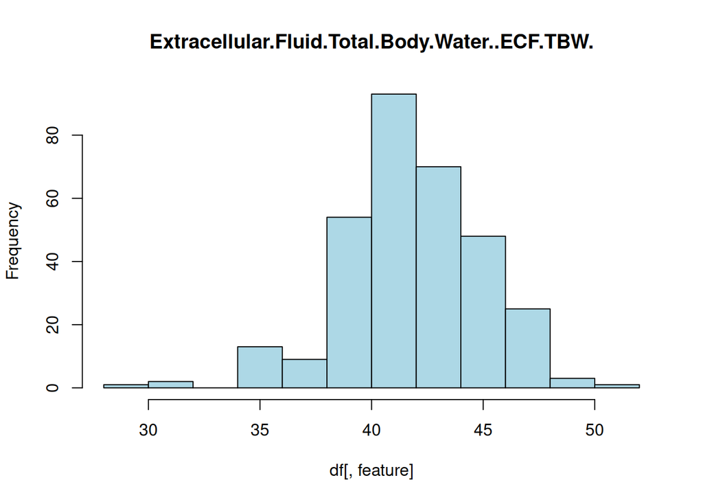

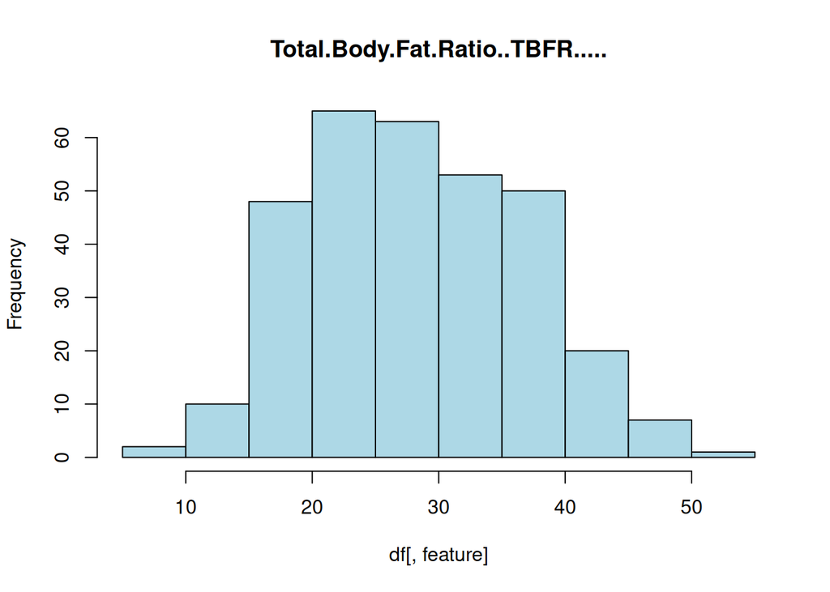

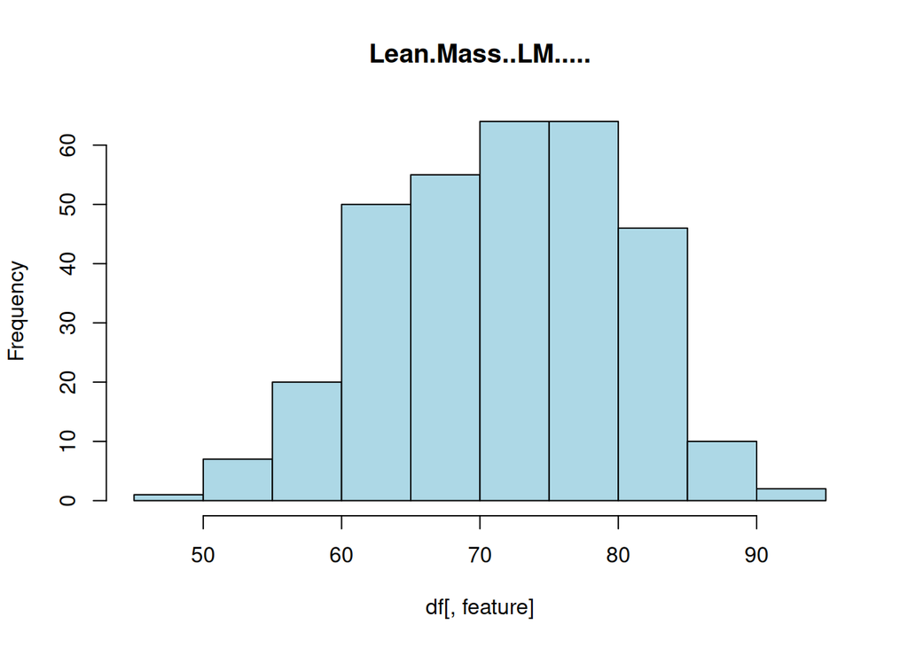

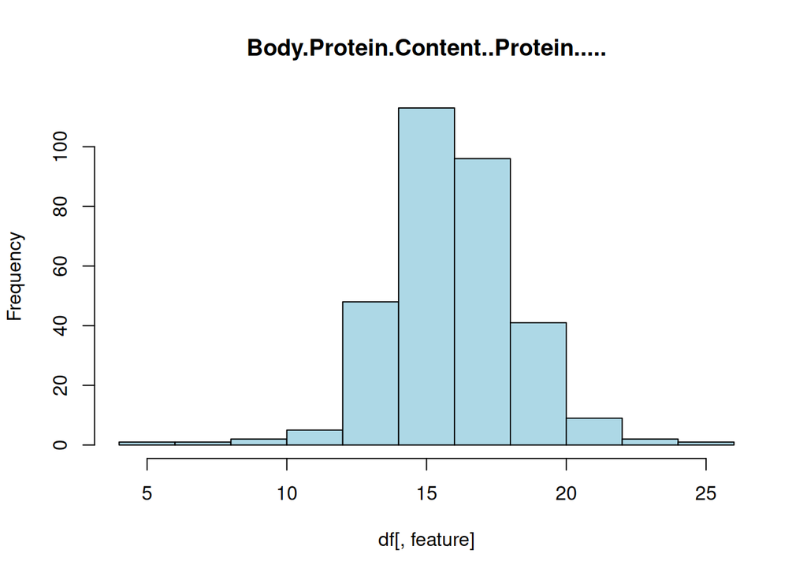

[21 more figures not shown]

```r
numeric_features <- setdiff(all_feature_names, categorical_features)

for(feature in numeric_features){

  hist(df[,feature],
       main = feature,
       col = "lightblue")
}
```

Here, we can see many features appear to be distributed normally, but many features are also right-skewed.

Given the number of features and the number of skewed features, we will assess skewedness using the following formula (the adjusted Fisher-Pearson standardized moment coefficient): *
$$\text{skewness} = \frac{n}{(n-1)(n-2)} \sum_{i=1}^{n} \left(\frac{x_i -
\bar{x}}{s}\right)^3$$

where:

- $n$ is the number of observations,
- $\bar{x}$ is the sample mean,
- $s$ is the sample standard deviation,
- and $x_i$ is the $i^{th}$ observation.
- Formula acquired using online sources, https://www.itl.nist.gov/div898/handbook/eda/section3/eda35b.htm, and created usingchatgpt.com

```r
skewness_base <- function(x) {
  n <- length(x)
  m <- mean(x)
  s <- sd(x)
  sum(((x - m)/s)^3) * (n / ((n - 1) * (n - 2)))
}

skewness_values <- sapply(df[, numeric_features], skewness_base)

skew_df <- data.frame(
  Feature = names(skewness_values),
  Skewness = skewness_values
)
rownames(skew_df) <- NULL
head(skew_df, 5)
```

```
##                 Feature   Skewness
## 1                   Age  0.1345809
## 2           Comorbidity  1.4471219
## 3                Height -0.0809294
## 4                Weight  0.4324519
## 5 Body.Mass.Index..BMI.  0.6693629
```

From the formula given above, we will determine skewness based upon a values greater than 0.5 or below -0.5. We will combine the results from the skewness formula and our visual inspection of the histograms to determine which features will need to be transformed.

```r
skewed_features <- skew_df[abs(skew_df$Skewness) > 0.5, ]

print(skewed_features)
```

```
##                                           Feature   Skewness
## 2                                     Comorbidity  1.4471219
## 5                           Body.Mass.Index..BMI.  0.6693629
## 8                       Intracellular.Water..ICW.  0.9521582
## 9  Extracellular.Fluid.Total.Body.Water..ECF.TBW. -0.5143227
## 13                      Visceral.Fat.Rating..VFR.  0.7978394
## 16                                    Obesity.... 16.8732333
## 17                        Total.Fat.Content..TFC.  0.8093633
## 18                        Visceral.Fat.Area..VFA.  1.0575396
## 21                                        Glucose  5.9378101
## 23                  Low.Density.Lipoprotein..LDL.  0.5402553
## 24                 High.Density.Lipoprotein..HDL.  6.5289476
## 25                                   Triglyceride  2.7863940
## 26                 Aspartat.Aminotransferaz..AST.  6.9945064
## 27                   Alanin.Aminotransferaz..ALT.  7.2769489
## 28                     Alkaline.Phosphatase..ALP.  0.7957852
## 29                                     Creatinine  0.6204646
## 30               Glomerular.Filtration.Rate..GFR. -1.8129747
## 31                       C.Reactive.Protein..CRP.  5.4111041
```

The skewness scores appears to appropriately classify skewedness of our features. However, there are some features that appear to be skewed because of outliers, in particular Obesity and Glomerular.Filtration.Rate..GFR. These features will likely become less skewed upon outlier removal. For example, in obesity, there is a single value at 1954 when the reamining values are below 500. It quite possible this value is a typo - instead of 1954, it should be 195.4. In comparison, for GFR, we see that the lowest value is at 10.6, when the average is at 100.8189028. Importantly, patients with a GFR below 60 are considered to have kidney disease; a patient with a GFR value of 10 is extremely low. However, unlike feature obesity, we cannot acertain if this is a typo, or a similar error, or simply an outlier in the data.

For obesity, we will assume it was a reasonable error and impute them. However, for GFR as we cannot know for certain, we will leave the value as is.

The remaining features, however, should be log transformed. Let us create a list for now:

```r
features_to_remove <- c("Obesity....")

skewed_features_names <- setdiff(skewed_features$Feature, features_to_remove)

skewed_features_subset <- skewed_features[skewed_features$Feature %in% skewed_features_names, ]
```

#### Assessment of Multicollinearity

Many models have issues with multicollinearity, therefore, it is imperative to assess multicollinearity of our features before choosing which models to employ.

```r
cor_mat <- cor(df)
high_corr <- which(cor_mat > 0.8 & cor_mat < 1, arr.ind = TRUE)

high_cor_df <- data.frame(
  Var1 = rownames(cor_mat)[high_corr[, 1]],
  Var2 = colnames(cor_mat)[high_corr[, 2]],
  Correlation = cor_mat[high_corr]
)
high_cor_df
```

```
##                               Var1                            Var2 Correlation
## 1          Visceral.Fat.Area..VFA.                          Weight   0.8815091
## 2          Total.Fat.Content..TFC.           Body.Mass.Index..BMI.   0.9027064
## 3          Visceral.Fat.Area..VFA.           Body.Mass.Index..BMI.   0.8496251
## 4        Extracellular.Water..ECW.          Total.Body.Water..TBW.   0.9043507
## 5        Intracellular.Water..ICW.          Total.Body.Water..TBW.   0.8172473
## 6                   Bone.Mass..BM.          Total.Body.Water..TBW.   0.8343463
## 7                 Muscle.Mass..MM.          Total.Body.Water..TBW.   0.9286334
## 8  Visceral.Muscle.Area..VMA...Kg.          Total.Body.Water..TBW.   0.8420972
## 9           Total.Body.Water..TBW.       Extracellular.Water..ECW.   0.9043507
## 10                  Bone.Mass..BM.       Extracellular.Water..ECW.   0.8205404
## 11                Muscle.Mass..MM.       Extracellular.Water..ECW.   0.8651977
## 12          Total.Body.Water..TBW.       Intracellular.Water..ICW.   0.8172473
## 13                Muscle.Mass..MM.       Intracellular.Water..ICW.   0.9040882
## 14 Visceral.Muscle.Area..VMA...Kg.       Intracellular.Water..ICW.   0.8025624
```

[output cut: 24 more lines]

We can see that many features are highly correlated with each other - 16 have multicollinearity. This, however, can be anticipated given the features themselves. For example, there are features denoting AST and ALT - markers of liver enzymes. These markers are often extremely correlated in individuals. Similarly, there are also features denoting cholesterol levels - Total Cholesterol and LDL. Like the liver enzymes, these are also commonly correlated.

### Model Choice

Given the data exploration, we need to choose three classification models. For this project, we will choose to utilize random forest trees, kNN, and ridge logistic regression models, as described below:

#### Model Choice: Random Forest Tree

Random forest trees are a classification model that handles multicollinearity, nonlinear relationships, and can tolerate outliers in our dataset. As such, it is an appropriate model for our requirements.

#### Model Choice: kNN

kNN models are good classification models for robustness for our ensemble, as well as flexibility. Although kNN models do not require handling of multicollinearity, it will benefit from it. Therefore, for out kNN model, we will need to remove outliers, normalize, log transform skewed features, and combine correlated features.

#### Model Choice: Ridge Logistic Regression

Regression provides a model variance for our entire ensemble. Further, ridge logistic regression can tolerate multicollinearity by using regularization coefficients to reduce the strength of large coefficients. For our ridge model, we will need to remove outliers, normalize, and log transform skewed features. Although we do not need to log transform our features, we will employ log transformation to improve its performance. Particularly because some features have strong right-skew.

## Data Shaping/Transformation

As mentioned during the data exploration phase, we have no missing values. For the requirements of this project, we will randomly remove datapoints in our dataset, and impute them.

```r
set.seed(123)  # For reproducibility

df_with_na <- df  # Make a copy

# Create dimensions excluding target feature
total_values <- prod(dim(df_with_na[,-1]))
num_NA <- round(total_values * 0.05)  # 5% missing

na_indices <- sample(total_values, num_NA, replace = FALSE)

row_indices <- ((na_indices - 1) %% nrow(df_with_na)) + 1
col_indices <- ((na_indices - 1) %/% nrow(df_with_na)) + 1

# Remove missing data across all features
for (i in seq_along(na_indices)) {
  df_with_na[row_indices[i]+1, col_indices[i]] <- NA
}

anyNA(df_with_na)
```

```
## [1] TRUE
```

```r
head(df_with_na)
```

```
##   Gallstone.Status Age Gender Comorbidity Coronary.Artery.Disease..CAD.
## 1                0  50      0           0                             0
## 2                0  47      0           1                             0
## 3                0  61      0           0                             0
## 4                0  41      0           0                             0
## 5                0  42      0           0                             0
## 6                0  96      0           0                             0
##   Hypothyroidism Hyperlipidemia Diabetes.Mellitus..DM. Height Weight
## 1              0              0                      0    185   92.8
## 2              0              0                      0    176   94.5
## 3              0              0                      0    171   91.1
## 4              0              0                      0    168   67.7
## 5             NA              0                      0    178   89.6
## 6              0              0                      0    155   49.0
##   Body.Mass.Index..BMI. Total.Body.Water..TBW. Extracellular.Water..ECW.
```

[output cut: 76 more lines]

Here we can see that we randomly removed missing values from our dataset. Although we only created missing values in 5% of the dataset, we will need to remove outliers for our kNN and ridge regression model. Therefore, it is helpful to maintain as many datapoints as possible for our training and evaluation.

To deal with missing values, we will impute them using the median. There are missing data across all features, instead of being concentrated in a single feature. Therefore, imputing values using the median will less likely introduce bias for each feature.

```r
# Function to get mode for categorical features
get_mode <- function(x) {
  uniq_vals <- unique(x[!is.na(x)])
  uniq_vals[which.max(tabulate(match(x, uniq_vals)))]
}

df_imputed <- df_with_na  # Copy dataframe with missing values

for (col in names(df_imputed)) {
  if (is.numeric(df_imputed[[col]])) {
    median_val <- median(df_imputed[[col]], na.rm = TRUE)
    df_imputed[[col]][is.na(df_imputed[[col]])] <- median_val
  } else {
    mode_val <- get_mode(df_imputed[[col]])
    df_imputed[[col]][is.na(df_imputed[[col]])] <- mode_val
  }
}

anyNA(df_imputed)
```

```
## [1] FALSE
```

Now, we have successfully created and imputed our missing values.

Imputing the maximum outlier in the obesity feature, assuming it is a typo and removing hyperlipidemia feature entirely (as explained in the exploration phase):

```r
# For Obesity....: find the max value, then replace it with max/10
max_val <- max(df_imputed$Obesity...., na.rm = TRUE)
max_index <- which(df_imputed$Obesity.... == max_val)
df_imputed$Obesity....[max_index] <- max_val / 10

df_imputed$Hyperlipidemia <- NULL
```

### Random Forest Tree

Random forest trees can handle multicollinearity, outliers, categorical features, and skewed features. As such, we only need to remove feature column hyperlipidemia as explained previously.

We will also factorize gallstone status, our target feature:

```r
df_rf <- df_imputed

# Convert target variable to factor
df_rf$Gallstone.Status <- as.factor(df_rf$Gallstone.Status)
```

### kNN

#### Feature Transformation - Multicollinearity and Data Distribution

kNN models are sensitive data to distribution (skewed data) and to multicollinearity. Therefore, we will transform the features first.

We will use the skewed feature list we determine previously to decide which features to apply log transformation to:

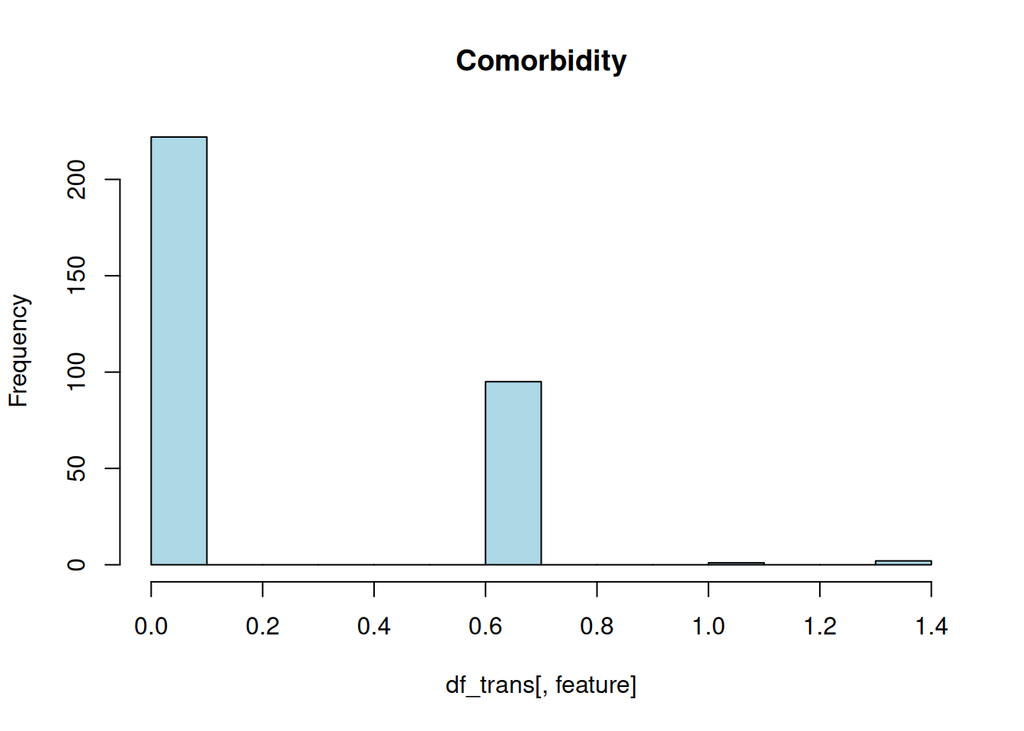

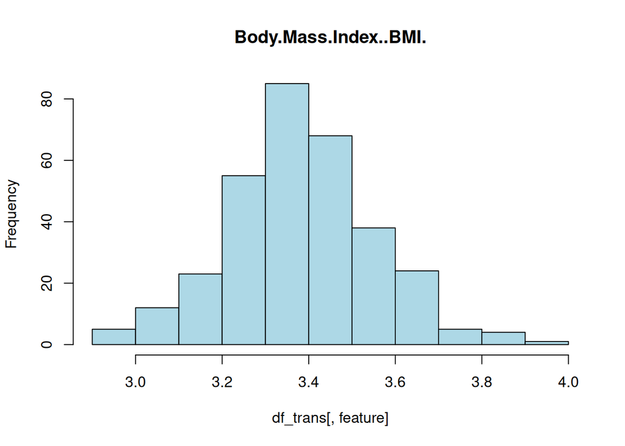

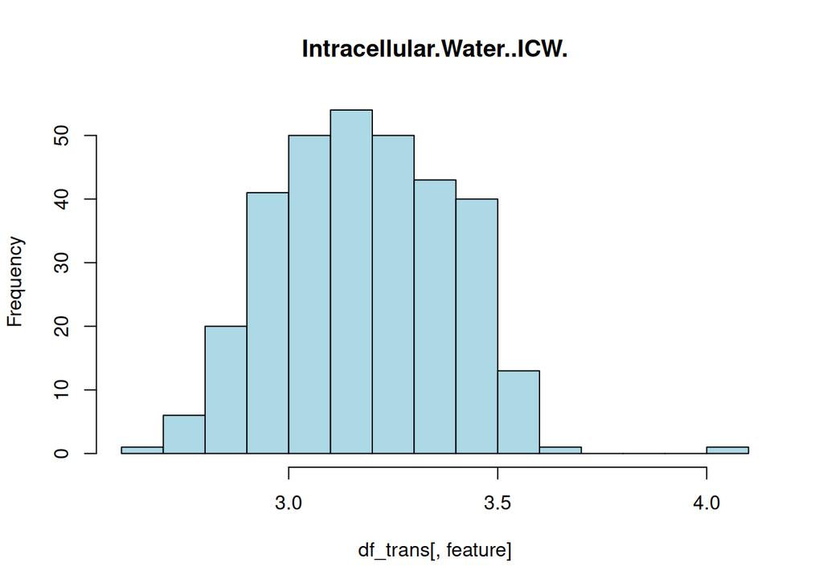

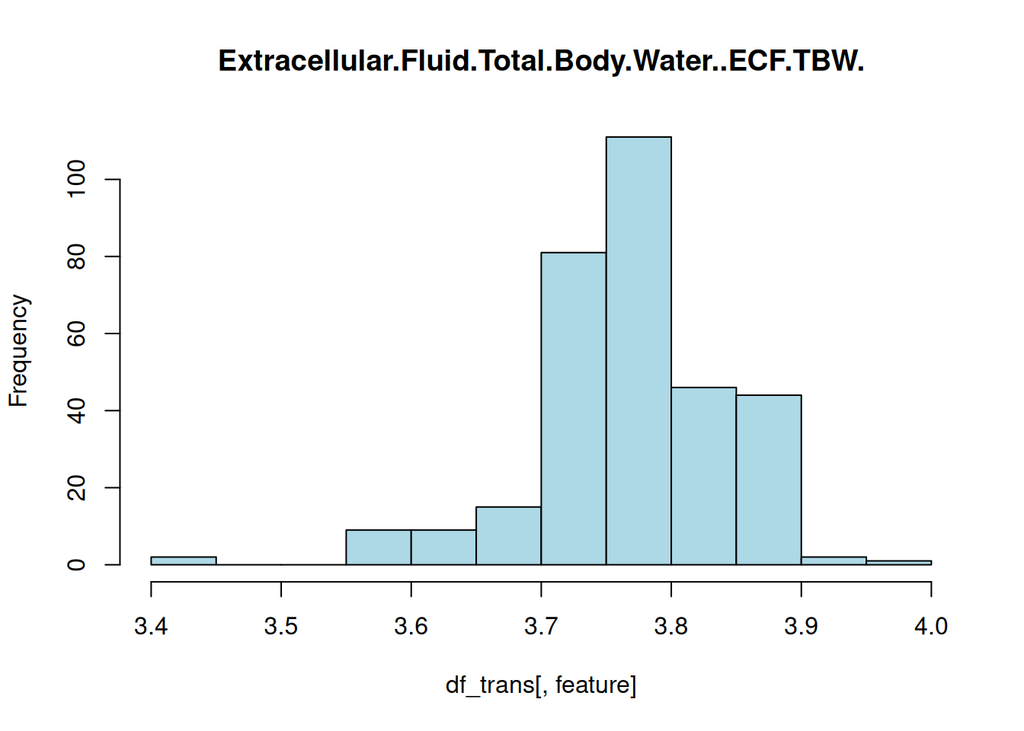

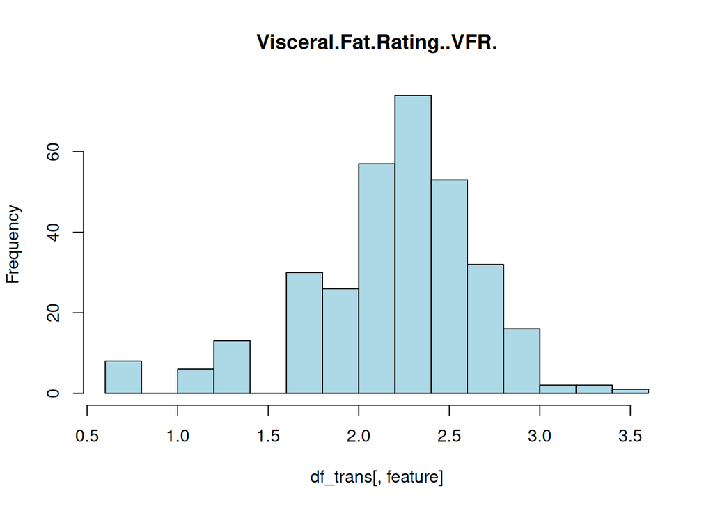

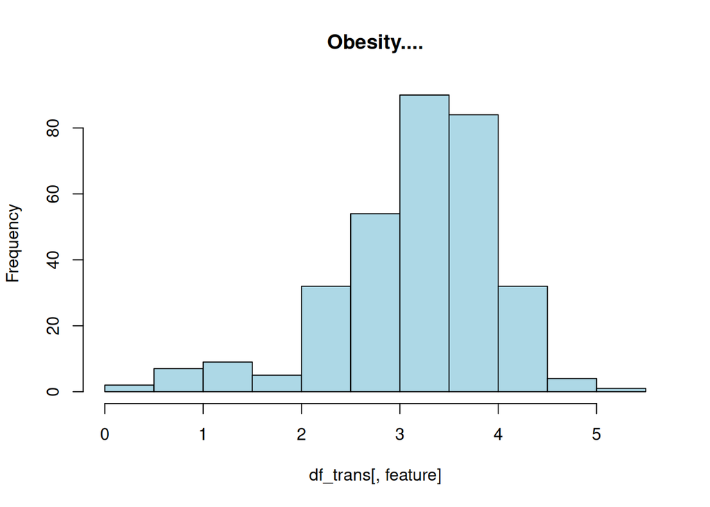

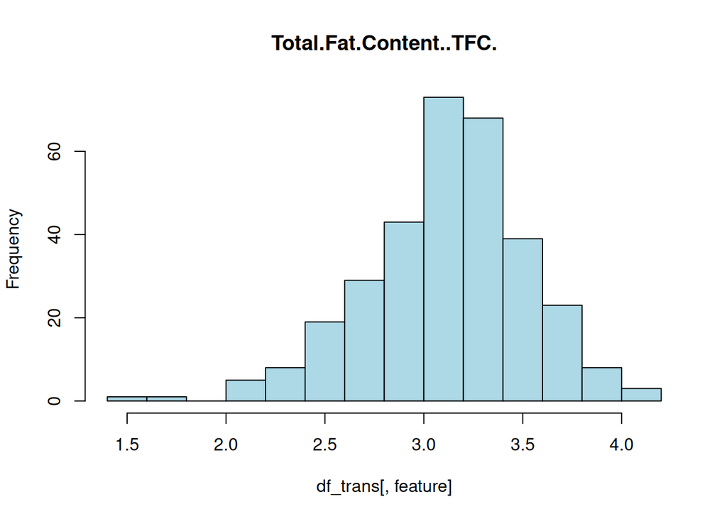

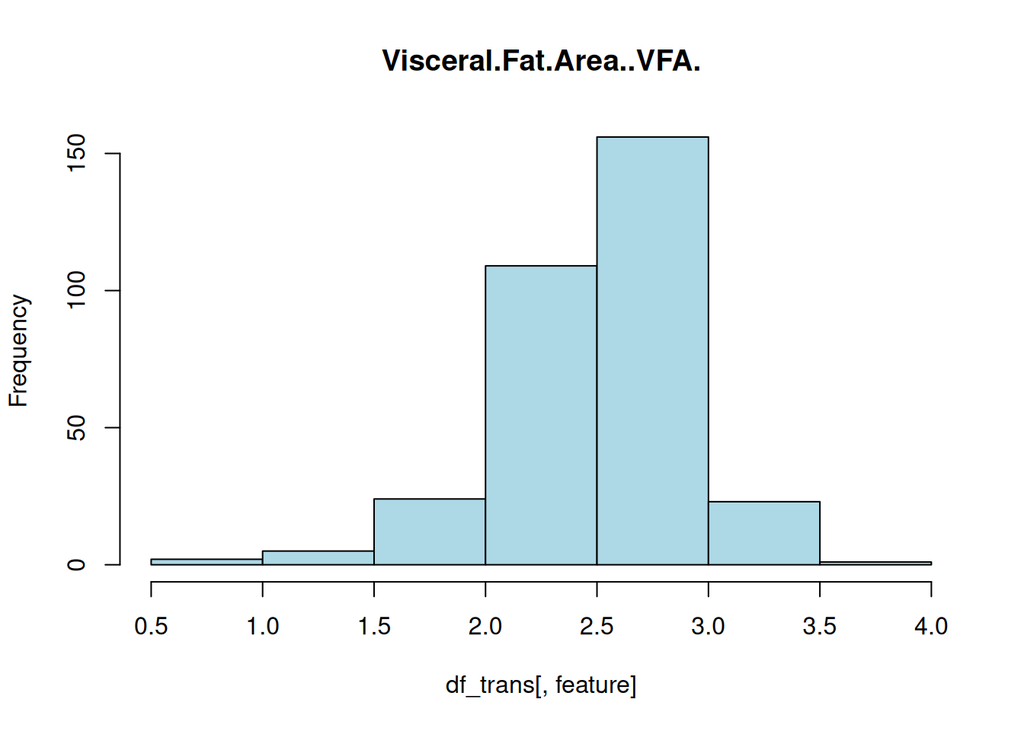

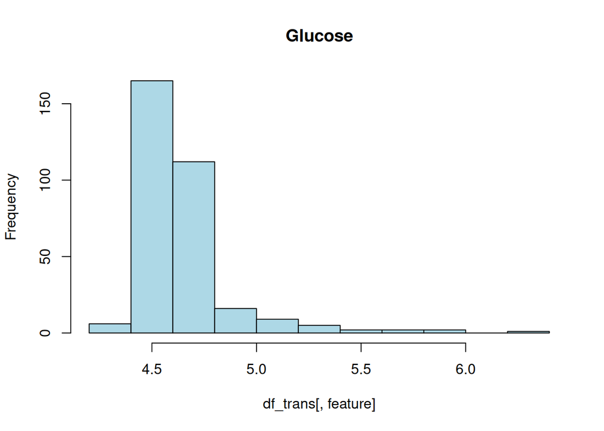

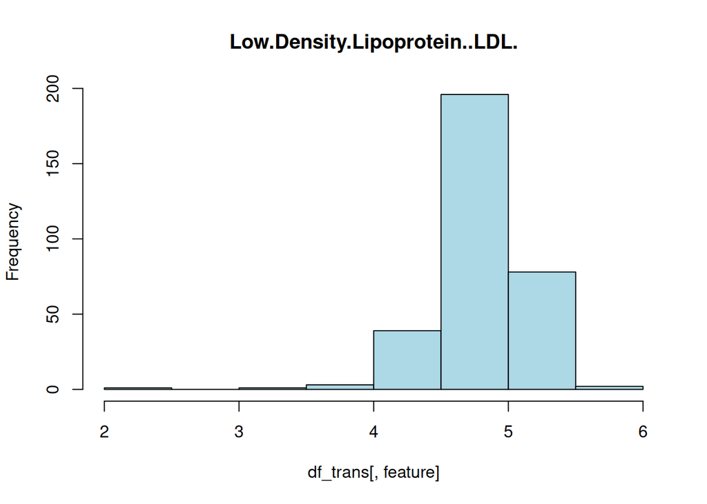

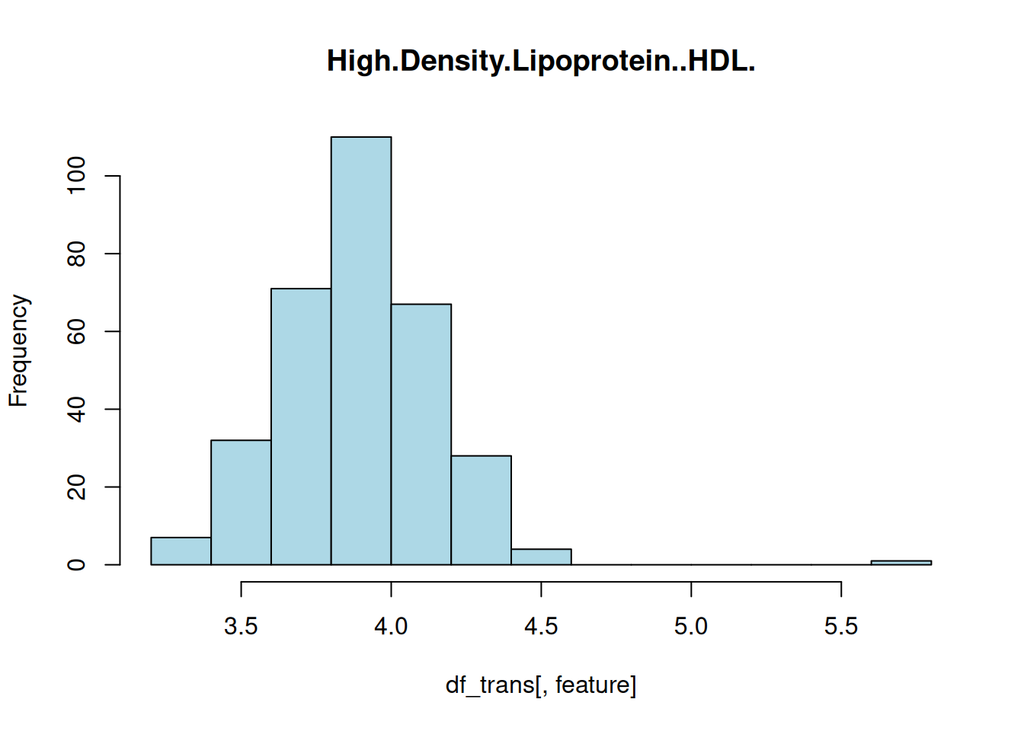

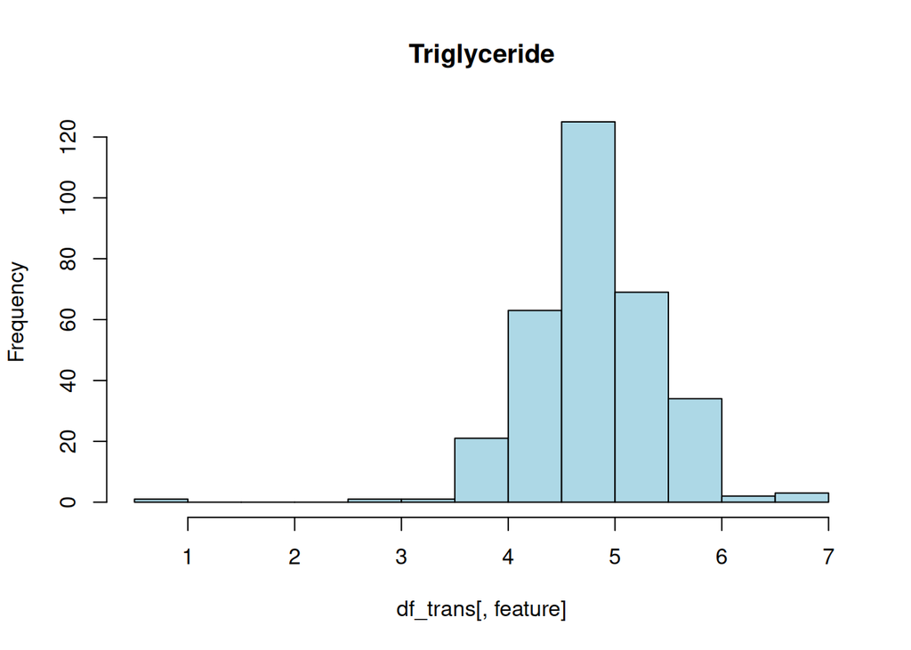

[6 more figures not shown]

```r
# Creaete log-transformed df copy
df_trans <- df_rf  # Copy dataframe with factorization of target variable

for (feature in skewed_features$Feature) {
  df_trans[[feature]] <- log(df_trans[[feature]] + 1)

  hist(df_trans[,feature],
       main = feature,
       col = "lightblue")
}
```

```r
# df_trans contains log-transformed dataframe
```

By assessing the distribution using histograms, we can see that the log transformed features are now more normally distributed. There are a few exceptions, most of them being due to outliers - for example GFR. However, the feature CRP is still substantially right-skewed, but better. Applying more transformations will be difficult, therefore, we will continue with this feature.

We will proceed to deal with multicollinearity of the dataset using the previously determined correlated features.

```r
high_cor_features <- unique(high_cor_df$Var1)

# 1. Extract the correlated features from df_log
correlated_data <- df_trans[, high_cor_features]

# 2. Run PCA on these features (center and scale recommended)
pca_result <- prcomp(correlated_data, center = TRUE, scale. = TRUE)

summary(pca_result)
```

```
## Importance of components:
##                           PC1    PC2    PC3     PC4     PC5    PC6     PC7
## Standard deviation     2.6972 1.8503 1.3357 1.13891 0.65325 0.5879 0.51961
## Proportion of Variance 0.4547 0.2140 0.1115 0.08107 0.02667 0.0216 0.01687
## Cumulative Proportion  0.4547 0.6687 0.7802 0.86124 0.88791 0.9095 0.92638
##                            PC8    PC9    PC10    PC11    PC12   PC13   PC14
## Standard deviation     0.48397 0.4437 0.42217 0.40619 0.36061 0.3324 0.2593
## Proportion of Variance 0.01464 0.0123 0.01114 0.01031 0.00813 0.0069 0.0042
## Cumulative Proportion  0.94102 0.9533 0.96446 0.97477 0.98290 0.9898 0.9940
##                           PC15   PC16
## Standard deviation     0.22941 0.2079
## Proportion of Variance 0.00329 0.0027
## Cumulative Proportion  0.99730 1.0000
```

Using the summary of our principle component analysis, we will choose the PCs so that it can account for roughly 90% of the variance. Given the PCA results, we will choose PC1~PC6 - as this accounts for majority of the variance.

```r
# Extract the first 5 PCs (multiple columns)
pc_selected <- pca_result$x[, 1:6]

# Remove the original correlated features from df_trans (make sure to use df_trans here)
df_trans_reduced <- df_trans[, !(names(df_trans) %in% high_cor_features)]

# Add the 5 PCs as new features with meaningful names
pc_names <- paste0("PC", 1:5)
df_trans_reduced[, pc_names] <- pc_selected
```

#### Outlier and Normalization

Traditionally, a z-score cut-off of 3.0 is used for outlier detection and removal. However, if our outliers are true outliers (i.e true measurements but high in comparison to our data), removing all of them may prevent our kNN model from appriorpiately predicting patients with unusually high blood work. Therefore, we will use a 3.5 cut-off to remove outliers that will substantially impact our kNN model performance, but still maintain a realistic spread of variance.

```r
# Normalization of numeric features
target_index <- which(colnames(df_trans_reduced) == 'Gallstone.Status')
df_scaled <- df_trans_reduced  # Because we want to keep gender encoding done previously

# Find Numeric features by finding categorical features first:
all_feature_names.trans <- setdiff(colnames(df_scaled), 'Gallstone.Status')
categorical_features.trans <- character()

for (feature in all_feature_names.trans){
  table_temp <- table(df_trans_reduced[feature])

  if (length(table_temp) <= 2){
    categorical_features.trans <- c(categorical_features.trans, feature)
  }
}

numeric_features.trans <- setdiff(all_feature_names.trans, categorical_features.trans)

# Scale only numeric features and remove outliers using z-score of 3.5
df_scaled[numeric_features.trans] <- scale(df_trans_reduced[,numeric_features.trans])

outliers_rows <- which(apply(abs(df_scaled[-target_index]) >= 3.5, 1, any))

length(outliers_rows)
```

```
## [1] 27
```

Here we identify that there are 27 outliers using a z-score cut-off of >= 3.5.

To remove the outliers, we will first split the dataset into the training and testing dataset using the indexes created above. First, we need to remove the outlier row numbers from the train and test indexes, then separate the data into training and testing datasets. We will also need to ensure that our remaining training and testing datasets have a 0.8~0.2 ratio and have similar ratios for our target variable gallstone status.

```r
df_kNN <- df_trans_reduced[-outliers_rows,]
df_kNN[numeric_features.trans] <- as.data.frame(scale(df_kNN[numeric_features.trans]))

table(df_kNN$Gallstone.Status)
```

```
##
##   0   1
## 157 136
```

#### Encoding Cateogorical Features

Now that we have detected and removed outliers, and normalized the dataset, we can encode our categorical features. Fortunately, except for gender, all categorical features are defaultly in a numeric form.

We will employ a one-shot encoding for gender:

```r
df_kNN$Female <- ifelse(df_kNN$Gender == 0, 1, 0)
df_kNN$Male <- ifelse(df_kNN$Gender == 1, 1, 0)

# Optionally, you can remove the original Gender column if you don't need it anymore
df_kNN$Gender <- NULL
```

### Ridge Logistic Regression

For this reason, we will scale our data frame and save it into a new variable df_ridge:

```r
# df_trans contains log transformed features

# Remove outliers
z_scores <- scale(df_trans[,numeric_features])
outlier_rows <- apply(abs(z_scores), 1, function(row) any(row > 3.5))
df_pre_ridge <- df_trans[!outlier_rows, ]

# Convert target to numeric
df_pre_ridge$Gallstone.Status <- as.numeric(df_pre_ridge[[target_index]]) - 1

# Scale dataframe
df_ridge <- df_pre_ridge
df_ridge[,numeric_features] <- scale(df_pre_ridge[,numeric_features])
```

## Homozygous Model Construction

Now that we have shaped the data for each model, we will proceed to construct a homozygous ensemble using random forest trees, kNN, and ridge logistic regression.

### Random Forest Tree

We will start with the random forest tree. Since random forest trees inherently use bagging, we will use the hold-out method to create our random forest tree model. To ensure that we have approrpiate target class balance, we will use the createDataPartition() function from the caret package. This will balance the number of positive and negative gallstone diagnoses in both the training and testing dataset.

```r
train_index_rf <-  createDataPartition(df_rf$Gallstone.Status, p = 0.8, list = FALSE)
train_df_rf <- df_rf[train_index_rf,]
test_df_rf <- df_rf[-train_index_rf,]
```

#### Evaluation Function

Before we continue, we will create an evaluation function that uses the predictions make by a model and the actual predictions to compute the accuracy, F1 score and a confusion matrix. This will provide us the ability to evaluate each individual model, and our ensemble.

```r
evaluate_model <- function(predictions, actual){
  conf_mat <- table(Predicted = predictions, Actual = actual)

  TP <- conf_mat["1", "1"]
  TN <- conf_mat["0", "0"]
  FP <- conf_mat["1", "0"]
  FN <- conf_mat["0", "1"]

  precision <- TP / (TP + FP)
  recall <- TP / (TP + FN)
  f1_score <- 2 * precision * recall / (precision + recall)

  accuracy <- (TP + TN) / (TP + TN + FP + FN)

  list(conf_mat = conf_mat, f1_score = f1_score, accuracy = accuracy)
}
```

In order to optimize our random forest tree, we need to optimize the number of decision trees, parameter ntree, and the number of features to consider at each node, ntree. To do this, we will create a function that creates and evaluates a random forest tree, subsequently, we will find the optimal parameters to tune our model.

```r
evaluate_rf <- function(train_data, test_data, mtry_val, ntree_val, seed = 123) {
  set.seed(seed)

  # Train RF
  rf_model <- randomForest(Gallstone.Status ~ ., data = train_data,
                             mtry = mtry_val, ntree = ntree_val)

  #Predict on test fold
  preds <- predict(rf_model, newdata = test_data)

  # Evaluate
  eval <- evaluate_model(preds, test_data$Gallstone.Status)

  fold_metrics <- data.frame(
     Accuracy = eval$accuracy,
     F1_Score = eval$f1_score,
     Predictions = preds

    )
   return(list(Accuracy = eval$accuracy,
               F1_Score = eval$f1_score,
               mtry = mtry_val,
               ntree = ntree_val,
               model = rf_model))
  }
```

Let us see a sample usage of the function:

```r
sample_rf_eval <- evaluate_rf(train_df_rf, test_df_rf, mtry_val = 7, ntree_val = 300)
sample_rf_eval
```

```
## $Accuracy
## [1] 0.7460317
##
## $F1_Score
## [1] 0.68
##
## $mtry
## [1] 7
##
## $ntree
## [1] 300
##
## $model
##
## Call:
##  randomForest(formula = Gallstone.Status ~ ., data = train_data,      mtry = mtry_val, ntree = ntree_val)
##                Type of random forest: classification
##                      Number of trees: 300
## No. of variables tried at each split: 7
##
##         OOB estimate of  error rate: 24.51%
## Confusion matrix:
##     0  1 class.error
## 0 115 25   0.1785714
## 1  38 79   0.3247863
```

Here a basic random forest tree, without tuning, predicted a test set with 0.7460317 accuracy and 0.68 F1 Score using a mtree value of 7 and an ntree value of 300.

Now, we will hyperparameterize both the number of decision trees and the number of features. To start, we will pick a standard range of between 100~600 for the number of trees, and a range betwee 2~half of the total number of features:

```r
ntree_values <- seq(100, 600, by = 100)

mtry_values <- c(2:floor(ncol(df)/2))

# Store evaluation metrics
k_fold_tuning <- data.frame()
k_tuning <- list()

set.seed(123)
for (nt in ntree_values) {
  for (m in mtry_values) {
    # Train model
    eval_out <- evaluate_rf(train_df_rf, test_df_rf, mtry_val = m, ntree_val = nt)


    k_fold_tuning <- rbind(k_fold_tuning, data.frame(
      ntree = nt,
      mtry = m,
      Accuracy = mean(eval_out$Accuracy),
      F1_Score = mean(eval_out$F1_Score)))

  }

}
max_index <- which.max(k_fold_tuning$Accuracy + k_fold_tuning$F1_Score)
rft_best_para <- k_fold_tuning[max_index,]

rft_best_para
```

```
##   ntree mtry  Accuracy F1_Score
## 4   100    5 0.7936508 0.754717
```

#### Final Random Forest Model

Now that we have built the determine the best parameters for our random forest tree, we can construct the homozygous random forest tree model:

```r
final_rf_model <- randomForest(Gallstone.Status ~ ., data = train_df_rf, mtry = rft_best_para$mtry, ntree = rft_best_para$ntree)
```

### kNN

Unlike the random forest tree, the kNN does not inherently do bagging. Therefore, we will have to implement bagging to improve our mode. Furthermore, unlike random forest trees, we cannot create a ‘model’ that can be subsequently used with the prediciton function predict(). Instead, the knn() function requires both the training and testing dataset, and outputs the predictions. Therefore, when we construct our kNN ensemble, we must retain our training datasets we use in order to apply our testing dataset during our heterozygous ensemble.

```r
train_kNN <- function(train_df, test_df, k_val, target_index){
  predictions <- knn(train = train_df[, -target_index],
                     test = test_df[, -target_index],
                     cl = train_df[[target_index]],
                     k = k_val)

  evaluation <- evaluate_model(predictions, test_df[[target_index]])
  return(list(
    Eval = evaluation,
    Preds = predictions))
}
```

Now that a kNN model function is created, let us create a function that determines the best k-value given a training dataset and testing dataset. This function will take a training dataframe, testing dataframe, a range of k-values, and the target index.

```r
best_k_knn <- function(train_df, test_df, k_values, target_index){

  knn_tuning <- data.frame()
  knn_evaluations <- list()

  for(k in k_values){
    knn_eval_output <- train_kNN(train_df, test_df, k, target_index)

    knn_eval <- knn_eval_output$Eval

    knn_tuning <- rbind(knn_tuning, data.frame(
      k = k,
      Accuracy = knn_eval$accuracy,
      F1_Score = knn_eval$f1_score)
      )
  }

  best_index <- which.max(knn_tuning$Accuracy + knn_tuning$F1_Score)

  return(list(
    Best_K = knn_tuning$k[best_index],
    Accuracy = knn_tuning$Accuracy[best_index],
    F1_Score = knn_tuning$F1_Score[best_index]
    ))
}

kNN_indics <- createDataPartition(df_kNN$Gallstone.Status, p = 0.8, list = FALSE)
train_kNN_df <- df_kNN[kNN_indics,]
test_kNN_df <- df_kNN[-kNN_indics,]

kNN_values <- seq(3, 19, by = 2)

sample_knn_model <- best_k_knn(train_kNN_df, test_kNN_df, kNN_values, 1)
sample_knn_model
```

```
## $Best_K
## [1] 19
##
## $Accuracy
## [1] 0.6551724
##
## $F1_Score
## [1] 0.4444444
```

Finally, let us create a function that takes an entire dataframe, in our case the dataset shaped for kNN, and split it n number of times into a 0.8~0.2 training to testing split. This function will in take a dataframe, a range of k_values, and the index of our target variable. It will return with the evaluation of the entire ensemble, and it will return with the training dataset subsets used for the model. This will ultimately create our kNN homozygous model, using bagging.

```r
kNN_bagged_models <- function(kNN_df, k_values, target_index, bag){
  set.seed(123)
  knn_evals <- data.frame()
  data_frames <- list()
  last_test_df <- NULL

  for (i in 1:bag) {

    indices <- createDataPartition(kNN_df[[target_index]], p = 0.8, list = FALSE)
    train_df <- kNN_df[indices, ]
    test_df <- kNN_df[-indices, ]

    best_k_result <- best_k_knn(train_df, test_df, k_values, target_index)

    knn_evals <- rbind(knn_evals, data.frame(
      Best_K = best_k_result$Best_K,
    Accuracy = best_k_result$Accuracy,
    F1_Score = best_k_result$F1_Score)
    )

    data_frames[[i]] <- train_df
    }

  return(list(
    results = knn_evals,
    data_frame = data_frames
  ))
}


kNN_models <- kNN_bagged_models(df_kNN, kNN_values, 1, 10)

knn_accuracy_avg <- mean(kNN_models$results$Accuracy)
knn_f1_score_avg <- mean(kNN_models$results$F1_Score)
```

Now we will build a function for the final ensemble, using the training dataframes each optimal k values. The function will take in the dataframes, the tuned k values, and a testing dataset.

```r
kNN_ensemble <- function(training_dfs, k_values, training_df, target_index){
  # training_dfs must be a list of dataframes
  # k_values must be a list of k values for each training dataframe
  predictions <- list()
  for (i in seq_along(k_values)){
    kNN_model <- train_kNN(training_dfs[[i]], training_df, k_values[[i]], target_index)
    preds <- kNN_model$Preds

    predictions[[i]] <- preds

  }
  return(predictions)
}

# Sample usage of Ensemble
ensemble <- kNN_ensemble(kNN_models$data_frame, kNN_models$results$Best_K, test_kNN_df, 1)
head(ensemble, 5)
```

```
## [[1]]
##  [1] 0 0 0 0 0 0 0 0 0 0 0 0 0 0 0 0 0 0 0 0 0 0 0 1 0 0 1 0 0 0 0 0 0 0 1 1 1 0
## [39] 0 0 1 0 0 1 1 1 1 1 1 1 1 1 0 0 0 0 0 0
## Levels: 0 1
##
## [[2]]
##  [1] 0 0 0 0 0 0 0 0 0 0 0 0 0 0 0 0 0 0 0 0 0 0 1 0 0 0 1 0 0 0 0 0 1 1 1 1 1 0
## [39] 0 0 1 0 1 1 1 1 0 1 1 1 0 1 1 0 1 1 1 0
## Levels: 0 1
##
## [[3]]
##  [1] 0 0 0 0 0 0 0 0 0 0 1 0 0 0 0 0 0 0 0 0 0 0 0 1 0 0 1 0 0 0 0 0 1 0 0 1 0 0
## [39] 0 0 1 1 1 1 0 0 0 1 1 1 0 1 0 0 1 0 0 0
## Levels: 0 1
##
## [[4]]
##  [1] 0 0 0 0 0 0 0 0 0 0 1 1 0 0 0 0 0 0 0 0 0 1 0 1 0 0 0 0 0 1 0 0 0 0 0 1 0 0
## [39] 1 0 1 1 0 1 1 1 0 1 1 1 0 1 0 0 1 0 0 1
## Levels: 0 1
##
## [[5]]
##  [1] 0 0 0 0 0 0 0 0 0 0 0 0 0 0 0 1 0 0 0 0 0 0 1 0 0 0 0 0 0 0 0 0 0 0 1 1 1 0
## [39] 1 0 1 1 1 1 0 1 1 1 1 1 1 1 0 0 1 0 0 0
## Levels: 0 1
```

### Ridge Logistic Regression

We move on to create the ridge logistic regression homologous model with bagging.

Like with kNN, we will build a function to tune and hyperparameterize alpha for our ridge logistic regression. We can optimize our ridge regression by optimizing the alpha parameter. The alpha parameter is used to regulate the size of the coefficients on our dataset. Given that we have substantial multicollinearity in numerous feature, optimizing alpha (as well as using ridge logistic regression) is ideal.

Below is a function that tests and optimizes alpha values for a given training and testing data set.

```r
ridge_alpha_tuning <- function(train_df, test_df, a_range, target_index = 1){
  set.seed(123)
  mat_train_df <- as.matrix(train_df)
  mat_test_df <- as.matrix(test_df)

  tuning_results <- data.frame()
  models_list <- list()

  for (a in a_range) {
    model <- cv.glmnet(
      x = mat_train_df[, -target_index],
      y = mat_train_df[, target_index],
      alpha = a,
      family = "binomial",
      maxit = 1e6
    )

    best_lambda <- model$lambda.min

    pred_probs <- predict(model, s = best_lambda, newx = mat_test_df[, -target_index], type = "response")

    pred_labels <- ifelse(pred_probs > 0.5, 1, 0)

    eval <- evaluate_model(pred_labels, mat_test_df[, target_index])

    tuning_results <- rbind(tuning_results, data.frame(
      Alpha = a,
      Accuracy = eval$accuracy,
      F1_Score = eval$f1_score
    ))

    models_list[[as.character(a)]] <- list(
      Model = model,
      Lambda = best_lambda,
      Evaluation = eval,
      Preds = pred_probs
    )
  }

  # Select best alpha by Accuracy + F1 Score
  tuning_results$Score <- tuning_results$Accuracy + tuning_results$F1_Score
  best_alpha <- as.character(tuning_results$Alpha[which.max(tuning_results$Score)])
  best_model_info <- models_list[[best_alpha]]

  return(list(
    Alpha = as.numeric(best_alpha),
    Accuracy = best_model_info$Evaluation$accuracy,
    F1_Score = best_model_info$Evaluation$f1_score,
    Model = best_model_info$Model
  ))
}
```

Let us test our function for optimizing k:

```r
set.seed(167)  # for reproducibility

# Assuming your target variable is called 'target'
ridge_train_index <- createDataPartition(df_ridge$Gallstone.Status, p = 0.8, list = FALSE)

train_ridge_df <- df_ridge[ridge_train_index, ]
test_ridge_df  <- df_ridge[-ridge_train_index, ]

alpha_ranges <- seq(0, 1, by = 0.1)
sample_ridge_tune <- ridge_alpha_tuning(train_ridge_df, test_ridge_df, alpha_ranges, 1)

sample_ridge_tune
```

```
## $Alpha
## [1] 0.3
##
## $Accuracy
## [1] 0.7368421
##
## $F1_Score
## [1] 0.7058824
##
## $Model
##
## Call:  cv.glmnet(x = mat_train_df[, -target_index], y = mat_train_df[,      target_index], alpha = a, family = "binomial", maxit = 1e+06)
##
## Measure: Binomial Deviance
##
##      Lambda Index Measure      SE Nonzero
## min 0.03305    35   1.038 0.09575      24
## 1se 0.16072    18   1.126 0.04975      11
```

Here we can see that the function is working and provides the accuracy (0.7368421), f1 score (0.7058824), model, and the alpha value 0.3.

#### Ridge Bagging and Functions

Now, we will create the ensemble with bagging:

```r
ridge_bagging <- function(train_df, test_df, alpha_ranges, target_index = 1, bags = 10) {
  models <- list()

  for (b in 1:bags) {
    # Bootstrap sample of training data
    indices <- sample(nrow(train_df), replace = TRUE)
    boot_train_df <- train_df[indices, ]

    # Alpha tuning on bootstrap sample
    ridge_model <- ridge_alpha_tuning(boot_train_df, test_df, alpha_ranges, target_index)

    # Store only the trained model
    models[[b]] <- ridge_model$Model
  }

  return(models)
}


ridge_models <- ridge_bagging(train_ridge_df, test_ridge_df, alpha_ranges, 1)
```

Finally, let us create a function to test each model for a different testing dataframe, ultimately creating the ensemble. This will be used later with to evaluate our ridge ensemble and combined with our other predictions to evaluate our entire ensemble.

```r
predict_ridge_models <- function(ridge_models, test_df, target_index = 1) {
  predictions_list <- vector("list", length(ridge_models))

  test_mat <- as.matrix(test_df[-1])

  for (i in seq_along(ridge_models)) {
    model <- ridge_models[[i]]

    # Get best lambda for this model
    lambda_best <- model$lambda.min

    # Predict probabilities on test set
    preds <- predict(model, s = lambda_best, newx = test_mat, type = "response")

    # Save predictions
    predictions_list[[i]] <- preds
  }

  return(predictions_list)
}

# Test function:
predictions_test <- predict_ridge_models(ridge_models, test_ridge_df, 1)
length(predictions_test)
```

```
## [1] 10
```

Here we can see that there are 10 predictions inside our ensemble.

Now that we have created all three individual ensembles, we will proceed to create the hetereozygous ensemble.

## Ensemble Creation and Evaluation

To evaluate the entire ensemble, we will split the dataset into 1/5 (or a 0.8~0.2) ratio, and test the the entire ensemble on the testing split. We will shape the data as required for each dataset, and use the models created previously to create individual ensembles, then average all using a majority vote for the entire ensemble.

Although the kNN model and ridge logistic regression requires removal of outliers, we will test the dataset without removing any. This is because the complete ensemble would, in theory, be used to predict gallstone status regardless if an individual patient has outlier tests. We need to acquire a realistic assessment of the entire ensemble. Therefore, we will not remove outliers.

### Testing Data for Ensemble

```r
set.seed(200)  # for reproducibility (optional)
test_indices <- sample(nrow(df), size = 0.2 * nrow(df))

# Since data preprocessing was done previously for each model, we can reuse the preprocessing
rf_ensemble_test <- df_rf[test_indices,]

# For kNN, we will need to reprocess the data so as to not remove the outliers.
kNN_ensemble_test <- df_scaled[test_indices,]  # model in kNN before removal of outliers
kNN_ensemble_test$Female <- ifelse(kNN_ensemble_test$Gender == 0, 1, 0)
kNN_ensemble_test$Male <- ifelse(kNN_ensemble_test$Gender == 1, 1, 0)

kNN_ensemble_test$Gender <- NULL

# For Ridge, we will need to reprocess the data so as to not remove the outliers.

ridge_ensemble_test <- df_trans[test_indices,] # model in ridge before removal of outliers and scaling
ridge_ensemble_test[,numeric_features] <- scale(ridge_ensemble_test[,numeric_features])

ensemble_target <- ridge_ensemble_test$Gallstone.Status
```

#### Individual Ensemble Assembly

Let’s create a function that takes a list of predictions and takes the majority vote. We will use this to compare each individual ensemble, and evaluate the entire ensemble.

```r
ensemble_probabilities <- function(prediction_list) {

  # Combine predictions into a matrix (rows = samples, columns = models)
  pred_matrix <- sapply(prediction_list, function(x) as.numeric(as.character(x)))

  # Convert values to numeric if they are factors or characters
  pred_matrix_num <- apply(pred_matrix, 2, function(col) as.numeric(as.character(col)))

  # Calculate probabilities as row means
  ensemble_probs <- rowMeans(pred_matrix_num)

  return(ensemble_probs)
}
```

```r
ensem_prob_list <- list()

# Random Forest Model saved in variable final_rf_model
rf_pred_array <- predict(final_rf_model, newdata = rf_ensemble_test, type = "prob")
rf_probs <- rf_pred_array[, "1"]  # Get list of predictions
ensem_prob_list[[1]] <- rf_probs

# Making Predictions using kNN
kNN_prediction_list <- kNN_ensemble(kNN_models$data_frame, kNN_models$results$Best_K, kNN_ensemble_test, 1)
kNN_probs <- ensemble_probabilities(kNN_prediction_list)
ensem_prob_list[[2]] <- kNN_probs

ridge_prediction_list <- predict_ridge_models(ridge_models, ridge_ensemble_test, 1)
ridge_probs <- ensemble_probabilities(ridge_prediction_list)
ensem_prob_list[[3]] <- ridge_probs

ensemble_probs <- ensemble_probabilities(ensem_prob_list)
```

### Evaluate Models

Now that we have created each ensemble, we will evaluate each model, create the entire ensemble using majority vote, and evaluate the overall ensemble.

```r
rf_prediction <- ifelse(rf_probs > 0.5, 1, 0)
rf_eval <- evaluate_model(rf_prediction, ensemble_target)

kNN_prediction <- ifelse(kNN_probs > 0.5, 1, 0)
kNN_eval <- evaluate_model(kNN_prediction, ensemble_target)

ridge_prediction <- ifelse(ridge_probs > 0.5, 1, 0)
ridge_eval <- evaluate_model(ridge_prediction, ensemble_target)

ensemble_prediction <- ifelse(ensemble_probs > 0.5, 1, 0)
ensemble_eval <- evaluate_model(ensemble_prediction, ensemble_target)
```

Finally, we have created each individual model, and the final heterozygous ensemble. Our overall ensemble performed quite well: an accuracy of 0.8571429, and an f1 score of 0.8571429. However, our individual models’s performance differed, with out random forest tree outperforming our ensemble: accuracy at 0.984127 and an f1 score of 0.9850746.

Below is a table comparing the performance of each individual model and the entire ensemble:

```r
evaluation_df <- data.frame(
  Models = c('Random Forest Tree', 'kNN', 'Ridge Logistic Regression', 'Entire Ensemble'),
  Accuracy = c(rf_eval$accuracy, kNN_eval$accuracy, ridge_eval$accuracy, ensemble_eval$accuracy),
  F1_Score = c(rf_eval$f1_score, kNN_eval$f1_score, ridge_eval$f1_score, ensemble_eval$f1_score)
)
evaluation_df
```

```
##                      Models  Accuracy  F1_Score
## 1        Random Forest Tree 0.9841270 0.9850746
## 2                       kNN 0.7777778 0.7666667
## 3 Ridge Logistic Regression 0.7777778 0.7812500
## 4           Entire Ensemble 0.8571429 0.8571429
```